# Drake_Zhou_Part_04_C

Drake Zhou

4/27/2022

# 1 Overview & Preparation

You must visualize the trends associated with the hardest to predict customer with respect to the most important sentiment derived feature. You are free to select whether you wish to visualize the regression model trends (log-transformed response) or the classification model trends (event probability).• Predictions should be made using the best performing model.

You must visualize your predictive trends using the following style: The primary input should be used as the x-aesthetic in a graphic. The secondary input should be used as a facet variable –it is recommended to use 4 to 6 unique values if your secondary input is a continuous variable. You must decide what values to use for the remaining inputs. What conclusions can you draw from the predictive trends?

## 1.1 Package Import

```r
library(caret)
library(yardstick)
library(tidyverse)
```

## 1.2 Data Import

```r
holdout <- readr::read_csv('final_project_holdout_inputs.csv', col_names = TRUE)
holdout_inputs <- holdout %>%
  select(-rowid)

df_all <- readr::read_csv("final_project_train.csv", col_names = TRUE)
# standard_df_all <- df_all %>%
#   select(starts_with("x"), region, customer) %>%
#   mutate(outcome = factor(df_all$outcome, levels = c("event", "non_event")),
#          region = df_all$region,
#          customer = df_all$customer)
df_all <- df_all %>%
  select(-rowid) %>%
  mutate(outcome = factor(outcome, levels = c("event", "non_event")))

# Resampling
train_id <- sample(1:nrow(df_all), size = floor(0.7 * nrow(df_all)))

train_ready <- df_all %>% slice(train_id)
test_ready <- df_all %>% slice(-train_id)
# test_ready <- df_all %>% slice(-train_id) %>% select(c(-response, -outcome, -rowid))
```

## 1.3 Model Import

```r
best_reg_mod <- readr::read_rds('models/fit_reg_enet_pair.rds')
best_cls_mod <- readr::read_rds('models/fit_acc_cat_nnet_tune.rds')
```

You must visualize the trends associated with the hardest to predict customer with respect to the most important sentiment derived feature.

You are free to select whether you wish to visualize the regression model trends (log-transformed response) or the classification model trends (event probability).

Predictions should be made using the best performing model.

# 2 Interpretation from Hold-out

## 2.1 Customer & sentiment derived feature

```r
df_format <- function(mod, test_data){
  my_conclu <- tibble::tibble(
  y = predict(mod, newdata = test_data),
  pred_outcome = predict(best_cls_mod, newdata = test_data)
  ) %>%
    bind_cols(
      predict(best_cls_mod, newdata = test_data, type = 'prob') %>%
        select(probability = event)
    ) %>%
  tibble::rowid_to_column('id')

  my_conclu_all <- test_data %>%
    mutate(pred_response = my_conclu$y,
           pred_outcome = factor(my_conclu$pred_outcome, levels = c("event", "non_event")),
           pred_prob = my_conclu$probability)
}

my_conclu_all_reg <- df_format(best_reg_mod, holdout_inputs)
my_conclu_all_cls <- df_format(best_cls_mod, holdout_inputs)
```

```r
my_conclu_all_reg %>%
  filter(customer == c("A","E","D", "Other"))
```

```
## # A tibble: 13 × 38
##    region customer xb_01 xb_02 xb_03  xn_01 xn_02 xn_03 xa_01 xa_02 xa_03  xb_04
##    <chr>  <chr>    <dbl> <dbl> <dbl>  <dbl> <dbl> <dbl> <dbl> <dbl> <dbl>  <dbl>
##  1 XX     Other     3.86     9     1  0.429     5    -7  7.71    17    -1  1.20
##  2 XX     Other     3.5      9     0  2.33      7     0  7.17    14     2  1.22
##  3 YY     Other     3.5      6    -1  1.5       5    -2 10.2     17     6  1.14
##  4 YY     D         4.89    13     1  2.05      8    -1 12.2     31     3  1.42
##  5 YY     E         1        1     1  0         0     0  0        0     0  0.25
##  6 YY     Other    -1       -1    -1 -2        -2    -2  3        3     3 -0.333
##  7 YY     Other     3.25     7    -1  2.25      4     0 11.5     19     4  0.867
##  8 YY     Other     2        2     2  4         4     4  6        6     6  1
##  9 YY     Other     4        7     1  1.5       3     0  9.5     11     8  0.8
## 10 ZZ     A         3.33     9     0  2.33      6     0  8.33    18     1  0.683
## 11 ZZ     A         8       10     6  3         4     2 18.5     24    13  2.33
## 12 ZZ     A         2        2     2  0         1    -1  4.5      6     3  1.5
## 13 ZZ     Other    -1       -1    -1 -4        -4    -4  4        4     4 -0.25
## # … with 26 more variables: xb_05 <dbl>, xb_06 <dbl>, xb_07 <dbl>, xb_08 <dbl>,
## #   xn_04 <dbl>, xn_05 <dbl>, xn_06 <dbl>, xn_07 <dbl>, xn_08 <dbl>,
## #   xa_04 <dbl>, xa_05 <dbl>, xa_06 <dbl>, xa_07 <dbl>, xa_08 <dbl>,
## #   xw_01 <dbl>, xw_02 <dbl>, xw_03 <dbl>, xs_01 <dbl>, xs_02 <dbl>,
## #   xs_03 <dbl>, xs_04 <dbl>, xs_05 <dbl>, xs_06 <dbl>, pred_response <dbl>,
## #   pred_outcome <fct>, pred_prob <dbl>
```

```r
  # ggplot(mapping = aes(x = xw_02, y = pred_response, color = xw_01)) +
  # geom_point() +
  # geom_smooth() +
  # geom_line()+
  # facet_wrap(~customer , labeller = "label_both", scales = "free")  +
  # ggthemes::scale_fill_colorblind() +
  # theme_bw()
```

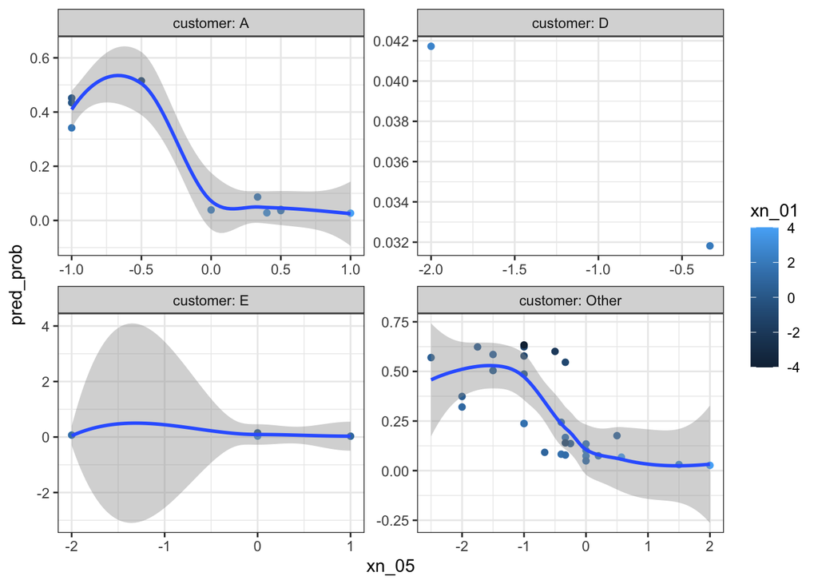

```r
my_conclu_all_cls %>%
  filter(customer %in% list("A","E","D", "Other")) %>%
  ggplot(mapping = aes(x = xn_05, y = pred_prob, color = xn_01)) +
  geom_point() +
  geom_smooth() +
  # geom_line()+
  facet_wrap(~customer , labeller = "label_both", scales = "free")  +
  ggthemes::scale_fill_colorblind() +
  theme_bw()
```

# 3 Predict trends

You must visualize your predictive trends using the following style: • The primary input should be used as the x-aesthetic in a graphic. • The secondary input should be used as a facet variable –it is recommended to use 4 to 6 unique values if your secondary input is a continuous variable. • You must decide what values to use for the remaining inputs. • What conclusions can you draw from the predictive trends?

## 3.1 Input grid prepare

```r
make_test_input_list <- function(var_name, top_4_inputs, all_data)
{
  xvar <- all_data %>% select(all_of(var_name)) %>% pull()

  if (var_name %in% top_4_inputs[1]){
    # use 25 unique values between the min/max values
    xgrid <- seq(min(xvar), max(xvar), length.out = 25)
  } else if (var_name %in% top_4_inputs[2]){
    # specify quantiles to use
    xgrid <- quantile(xvar, probs = c(0.05, 0.25, 0.5, 0.75, 0.95), na.rm = TRUE)
    xgrid <- as.vector(xgrid)
  } else if (var_name == "customer") {
    # keep the same data if its customer data
    xgrid <- xvar
  } else {
    # set to their median values
    xgrid <- median(xvar, na.rm = TRUE)
  }

  return(xgrid)
}
```

The second function, make_test_input_grid(), is a wrapper function. It iteratively applies the make_test_input_list() function to all inputs and then uses the expand.grid() function to create full factorial grid based on the list of unique input values.

```r
make_test_input_grid <- function(all_input_names, top_4_inputs, all_data)
{
  test_list <- purrr::map(all_input_names,
                          make_test_input_list,
                          top_4_inputs = top_4_inputs,
                          all_data = all_data)

  expand.grid(test_list,
              KEEP.OUT.ATTRS = FALSE,
              stringsAsFactors = FALSE) %>%
    purrr::set_names(all_input_names)
}
```

```r
my_input_names <- holdout_inputs %>% names()
my_top_ranked_inputs <- c("xn_05","xn_01")

viz_input_grid_cls <- make_test_input_grid(my_input_names, c("xn_05","xn_01"), holdout_inputs)
viz_input_grid_reg <- make_test_input_grid(my_input_names, c("xw_02","xw_01"), holdout_inputs)
```

## 3.2 Making prediction

```r
my_pred_all_reg <- df_format(best_reg_mod, viz_input_grid_reg)
my_pred_all_cls <- df_format(best_cls_mod, viz_input_grid_cls)
```

## 3.3 Visualize trends

### 3.3.1 Classification Model

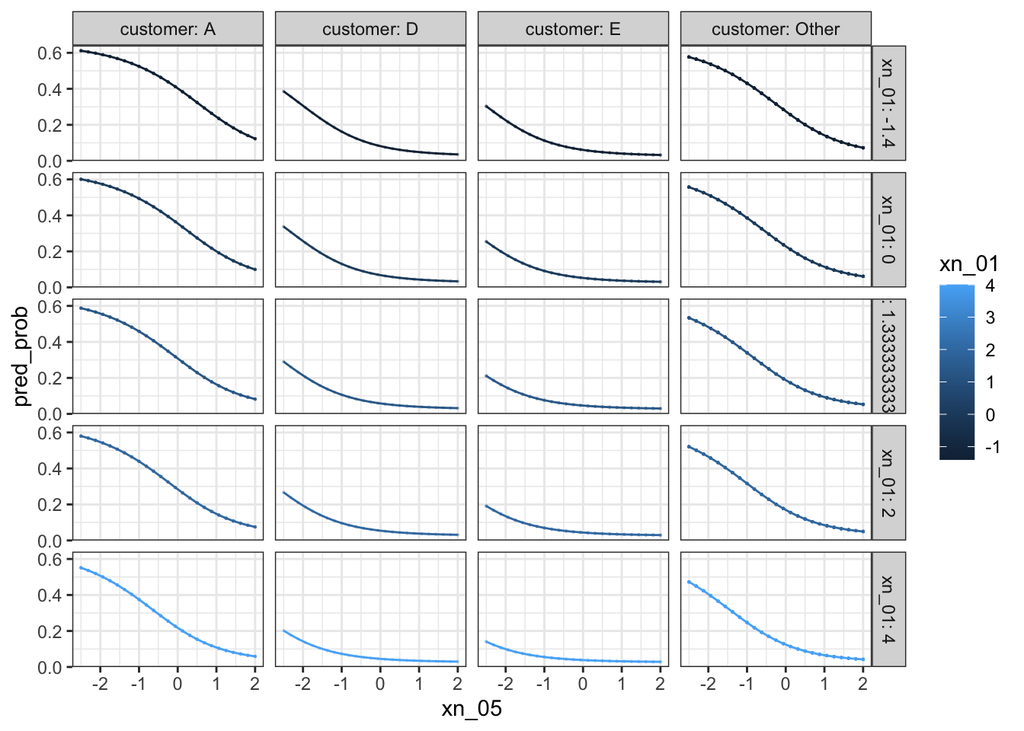

```r
my_pred_all_cls %>%
  filter(customer %in% list("A","E","D", "Other")) %>%
  ggplot(mapping = aes(x = xn_05, y = pred_prob, color = xn_01)) +
  geom_point(size = 0.1, alpha = 0.2) +
  geom_line()+
  # geom_smooth() +
  facet_grid(xn_01 ~ customer, labeller = "label_both", scales = "fix")  +
  ggthemes::scale_fill_colorblind() +
  theme_bw()
```

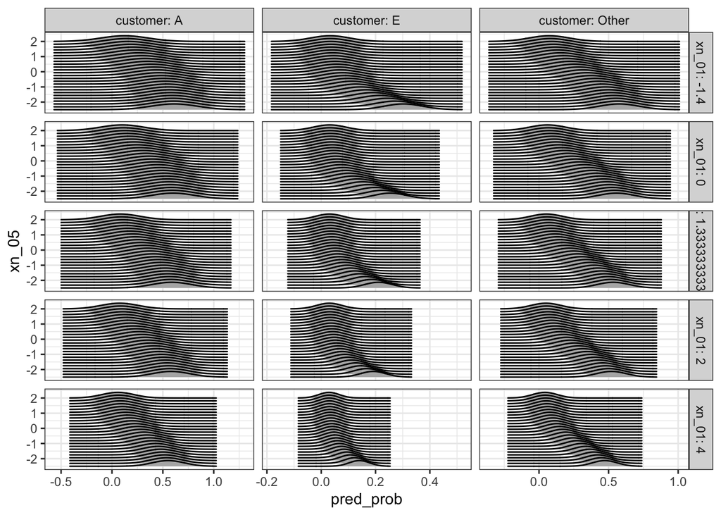

```r
library(ggridges)
my_pred_all_cls %>%
  filter(customer %in% list("A","E", "Other")) %>%
  ggplot(aes(x = pred_prob, y = xn_05, group = xn_05)) +
  geom_density_ridges(scale = 2)+
  facet_grid(xn_01 ~ customer, labeller = "label_both", scales = "free")  +
  ggthemes::scale_fill_colorblind() +
  theme_bw()
```

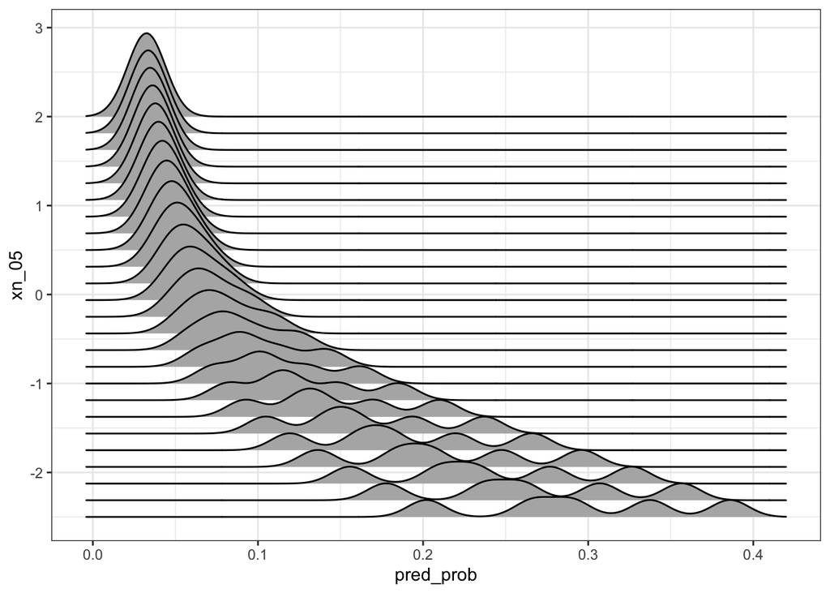

```r
my_pred_all_cls %>%
  filter(customer == "D") %>%
  ggplot(aes(x = pred_prob, y = xn_05, group = xn_05)) +
  geom_density_ridges(scale = 5)+
  # facet_grid(~ xn_01, labeller = "label_both", scales = "free")  +
  ggthemes::scale_fill_colorblind() +
  theme_bw()
```

This figure we take a close look to customer D, as we can see, the model turns into multi peak model, that could be a reason why this customer is hard to predict.

### 3.3.2 Regression Model

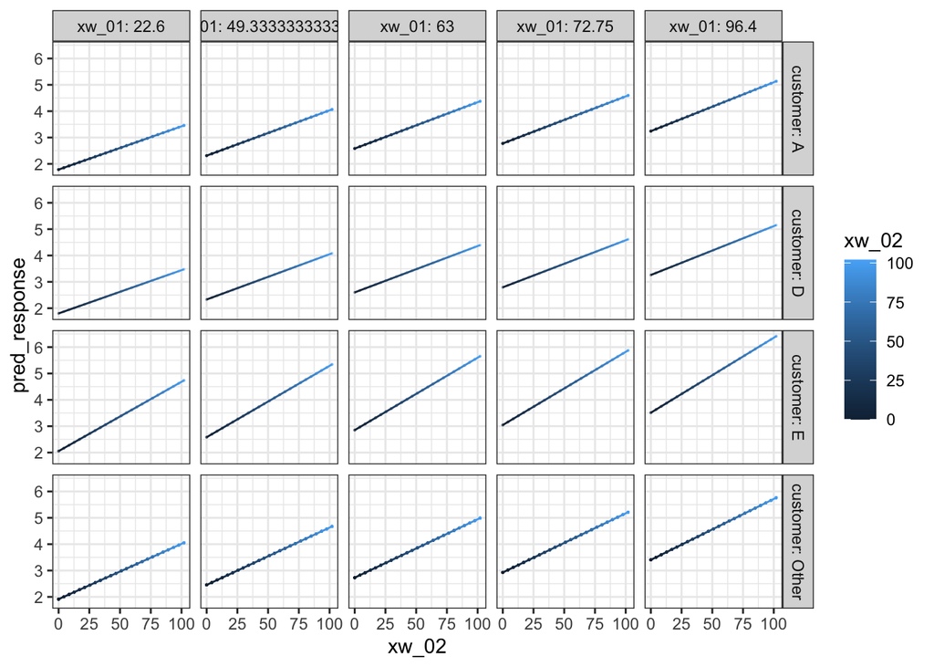

```r
my_pred_all_reg %>%
  filter(customer %in% list("A","E","D", "Other")) %>%
  ggplot(mapping = aes(x = xw_02, y = pred_response, color = xw_02)) +
  geom_point(size = 0.1, alpha = 0.2) +
  geom_line()+
  # geom_smooth() +
  facet_grid(customer ~ xw_01, labeller = "label_both", scales = "fix")  +
  ggthemes::scale_fill_colorblind() +
  theme_bw()
```

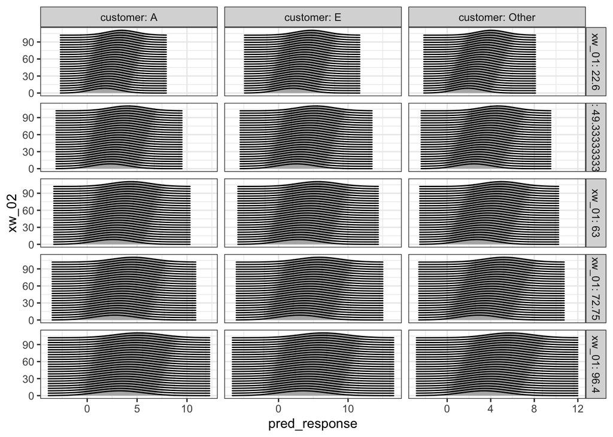

```r
library(ggridges)
my_pred_all_reg %>%
  filter(customer %in% list("A","E","Other")) %>%
  ggplot(aes(x = pred_response, y = xw_02, group = xw_02)) +
  geom_density_ridges(scale = 2)+
  facet_grid(xw_01 ~ customer, labeller = "label_both", scales = "free")  +
  ggthemes::scale_fill_colorblind() +
  theme_bw()
```

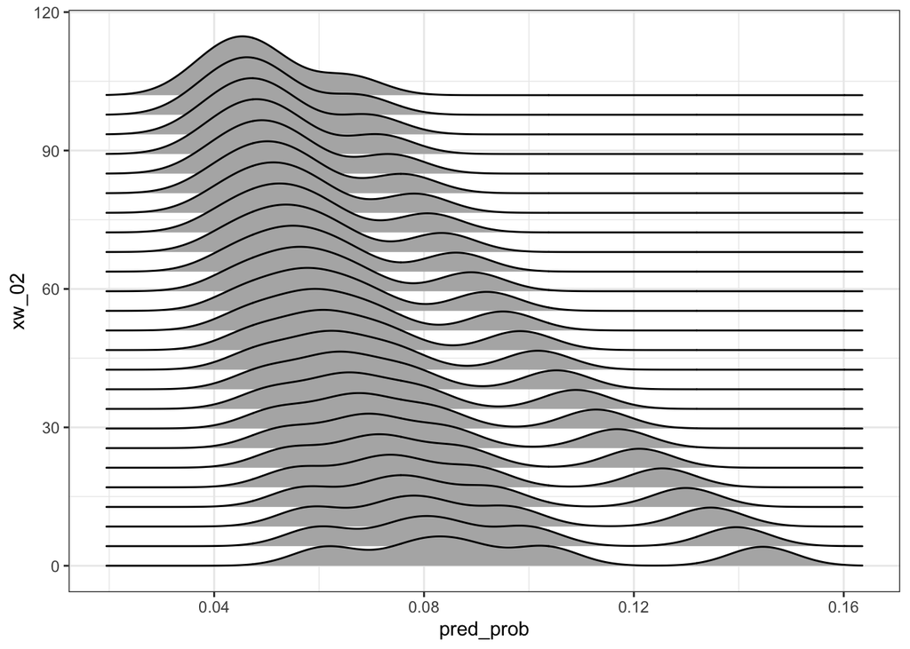

```r
my_pred_all_reg %>%
  filter(customer == "D") %>%
  ggplot(aes(x = pred_prob, y = xw_02, group = xw_02)) +
  geom_density_ridges(scale = 3)+
  # facet_grid(xw_01 ~ ., labeller = "label_both", scales = "free")  +
  ggthemes::scale_fill_colorblind() +
  theme_bw()
```